# Aboriginal Australia 1970-1979

Matti Munk Nielsen

11 May 2024

# Download

## Library

```r
library(tidyverse)
```

```r
library(tidytext)
library(ggwordcloud)
```

## Read the csv.file

```r
Aboriginal_1970_1979 <- read_csv("Aboriginal_Australia_1970-1979.csv")
```

## Show csv.file

```r
Aboriginal_1970_1979
```

```
## # A tibble: 100 × 14
##    article_text     article_id article_URL article_heading category article_date
##    <chr>                 <dbl> <chr>       <chr>           <chr>    <date>
##  1 "Aboriginal   M…  110833545 https://ap… Aboriginal      Article  1977-01-05
##  2 "Aboriginal   T…  131690079 https://ap… Aboriginal      Article  1973-11-03
##  3 "Aboriginal   O…  136991166 https://ap… Aboriginal      Article  1974-10-14
##  4 "Aboriginal   T…  110655562 https://ap… Aboriginal      Article  1975-08-29
##  5 "Aboriginal   '…  102005731 https://ap… Aboriginal 'em… Article  1972-09-25
##  6 "Aboriginal  pr…  110448185 https://ap… Aboriginal pri… Article  1971-01-11
##  7 "Aboriginal   r…  110607026 https://ap… Aboriginal rig… Article  1979-10-20
##  8 "ABORIGINAL  PR…  250568925 https://ap… ABORIGINAL PRO… Article  1976-11-04
##  9 "Aboriginal  he…  259553057 https://ap… Aboriginal hea… Article  1979-08-01
## 10 "Aboriginal  ca…  102005113 https://ap… Aboriginal can… Article  1972-09-20
## # ℹ 90 more rows
## # ℹ 8 more variables: article_page <dbl>, article_page_sequence <dbl>,
## #   article_snippet <chr>, article_Trove_URL <chr>, article_title_id <dbl>,
## #   article_title_title <chr>, article_relevance_score <dbl>,
## #   article_relevance_value <chr>
```

# Textmining

## Unnest tokens

Unnest tokens separates individual words from the articles in a column.

```r
Aboriginal_1970_1979_tokens <-Aboriginal_1970_1979 %>%
  unnest_tokens(word,article_text)

Aboriginal_1970_1979_tokens
```

```
## # A tibble: 21,590 × 14
##    article_id article_URL     article_heading category article_date article_page
##         <dbl> <chr>           <chr>           <chr>    <date>              <dbl>
##  1  110833545 https://api.tr… Aboriginal      Article  1977-01-05              3
##  2  110833545 https://api.tr… Aboriginal      Article  1977-01-05              3
##  3  110833545 https://api.tr… Aboriginal      Article  1977-01-05              3
##  4  110833545 https://api.tr… Aboriginal      Article  1977-01-05              3
##  5  110833545 https://api.tr… Aboriginal      Article  1977-01-05              3
##  6  110833545 https://api.tr… Aboriginal      Article  1977-01-05              3
##  7  110833545 https://api.tr… Aboriginal      Article  1977-01-05              3
##  8  110833545 https://api.tr… Aboriginal      Article  1977-01-05              3
##  9  110833545 https://api.tr… Aboriginal      Article  1977-01-05              3
## 10  110833545 https://api.tr… Aboriginal      Article  1977-01-05              3
## # ℹ 21,580 more rows
## # ℹ 8 more variables: article_page_sequence <dbl>, article_snippet <chr>,
## #   article_Trove_URL <chr>, article_title_id <dbl>, article_title_title <chr>,
## #   article_relevance_score <dbl>, article_relevance_value <chr>, word <chr>
```

## Count words

```r
Aboriginal_1970_1979_wc <- Aboriginal_1970_1979_tokens%>%
  count(word)%>%
  arrange(-n)

Aboriginal_1970_1979_wc
```

```
## # A tibble: 4,637 × 2
##    word           n
##    <chr>      <int>
##  1 the         1513
##  2 of           761
##  3 to           572
##  4 and          545
##  5 in           457
##  6 a            418
##  7 aboriginal   400
##  8 that         260
##  9 for          255
## 10 is           220
## # ℹ 4,627 more rows
```

## Stopwordslist

A stopwordslist is a list of all the stopwords in all the 100 articles.

```r
Aboriginal_1970_1979_wc
```

```
## # A tibble: 4,637 × 2
##    word           n
##    <chr>      <int>
##  1 the         1513
##  2 of           761
##  3 to           572
##  4 and          545
##  5 in           457
##  6 a            418
##  7 aboriginal   400
##  8 that         260
##  9 for          255
## 10 is           220
## # ℹ 4,627 more rows
```

## Remove stopwordslist

```r
Aboriginal_1970_1979_stop <- Aboriginal_1970_1979_tokens%>%
  anti_join(stop_words)
Aboriginal_1970_1979_stop
```

```
## # A tibble: 9,951 × 14
##    article_id article_URL     article_heading category article_date article_page
##         <dbl> <chr>           <chr>           <chr>    <date>              <dbl>
##  1  110833545 https://api.tr… Aboriginal      Article  1977-01-05              3
##  2  110833545 https://api.tr… Aboriginal      Article  1977-01-05              3
##  3  110833545 https://api.tr… Aboriginal      Article  1977-01-05              3
##  4  110833545 https://api.tr… Aboriginal      Article  1977-01-05              3
##  5  110833545 https://api.tr… Aboriginal      Article  1977-01-05              3
##  6  110833545 https://api.tr… Aboriginal      Article  1977-01-05              3
##  7  110833545 https://api.tr… Aboriginal      Article  1977-01-05              3
##  8  110833545 https://api.tr… Aboriginal      Article  1977-01-05              3
##  9  110833545 https://api.tr… Aboriginal      Article  1977-01-05              3
## 10  110833545 https://api.tr… Aboriginal      Article  1977-01-05              3
## # ℹ 9,941 more rows
## # ℹ 8 more variables: article_page_sequence <dbl>, article_snippet <chr>,
## #   article_Trove_URL <chr>, article_title_id <dbl>, article_title_title <chr>,
## #   article_relevance_score <dbl>, article_relevance_value <chr>, word <chr>
```

## Count words again

```r
Aboriginal_1970_1979_swc <- Aboriginal_1970_1979_stop%>%
  count(word)%>%
  arrange(-n)

Aboriginal_1970_1979_swc
```

```
## # A tibble: 4,126 × 2
##    word           n
##    <chr>      <int>
##  1 aboriginal   400
##  2 aborigines   104
##  3 people        93
##  4 government    76
##  5 land          62
##  6 affairs       61
##  7 australian    53
##  8 australia     51
##  9 white         46
## 10 rights        42
## # ℹ 4,116 more rows
```

## Show Aboriginal 1970 to 1979 swc Head

```r
 Aboriginal_1970_1979_swc%>%
  head(10)
```

```
## # A tibble: 10 × 2
##    word           n
##    <chr>      <int>
##  1 aboriginal   400
##  2 aborigines   104
##  3 people        93
##  4 government    76
##  5 land          62
##  6 affairs       61
##  7 australian    53
##  8 australia     51
##  9 white         46
## 10 rights        42
```

## Remove nontext

```r
Aboriginal_1970_1979_no_numeric <- Aboriginal_1970_1979_stop%>%
  filter(is.na(as.numeric(word)))
```

## View nontext

```r
Aboriginal_1970_1979_no_numeric
```

```
## # A tibble: 9,757 × 14
##    article_id article_URL     article_heading category article_date article_page
##         <dbl> <chr>           <chr>           <chr>    <date>              <dbl>
##  1  110833545 https://api.tr… Aboriginal      Article  1977-01-05              3
##  2  110833545 https://api.tr… Aboriginal      Article  1977-01-05              3
##  3  110833545 https://api.tr… Aboriginal      Article  1977-01-05              3
##  4  110833545 https://api.tr… Aboriginal      Article  1977-01-05              3
##  5  110833545 https://api.tr… Aboriginal      Article  1977-01-05              3
##  6  110833545 https://api.tr… Aboriginal      Article  1977-01-05              3
##  7  110833545 https://api.tr… Aboriginal      Article  1977-01-05              3
##  8  110833545 https://api.tr… Aboriginal      Article  1977-01-05              3
##  9  110833545 https://api.tr… Aboriginal      Article  1977-01-05              3
## 10  110833545 https://api.tr… Aboriginal      Article  1977-01-05              3
## # ℹ 9,747 more rows
## # ℹ 8 more variables: article_page_sequence <dbl>, article_snippet <chr>,
## #   article_Trove_URL <chr>, article_title_id <dbl>, article_title_title <chr>,
## #   article_relevance_score <dbl>, article_relevance_value <chr>, word <chr>
```

## Unique words

```r
length(unique(Aboriginal_1970_1979_no_numeric$word))
```

```
## [1] 4040
```

## Top 100 words

Show the 100 most used words in all the 100 articles.

```r
Aboriginal_1970_1979_top100 <- Aboriginal_1970_1979_no_numeric%>%
  count(word)%>%
  arrange(-n)%>%
  head(100)

Aboriginal_1970_1979_top100
```

```
## # A tibble: 100 × 2
##    word           n
##    <chr>      <int>
##  1 aboriginal   400
##  2 aborigines   104
##  3 people        93
##  4 government    76
##  5 land          62
##  6 affairs       61
##  7 australian    53
##  8 australia     51
##  9 white         46
## 10 rights        42
## # ℹ 90 more rows
```

## Cloud

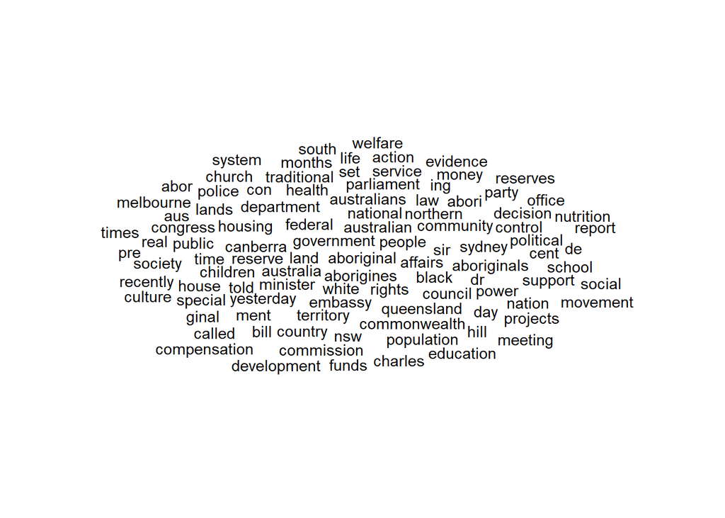

```r
Aboriginal_1970_1979_cloud <- ggplot(data = Aboriginal_1970_1979_top100, aes( label = word)) + geom_text_wordcloud() + theme_minimal()

Aboriginal_1970_1979_cloud
```

## Customize cloud

Shows the most frequent used words from the 100 articles where green is most,then yellow and last pink.

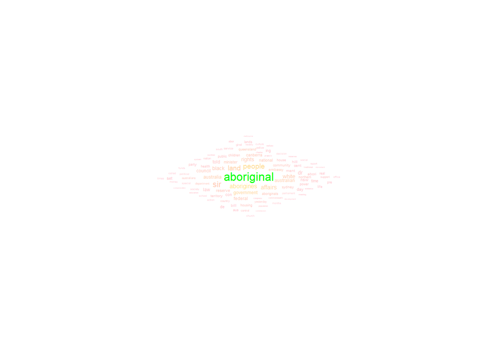

```r
ggplot(data = Aboriginal_1970_1979_top100, aes(label = word, size = n)) +
  geom_text_wordcloud_area(aes(color = n), shape = "diamond") +
  scale_size_area(max_size = 12) +
  scale_color_gradientn(colors = c("pink", "yellow", "green")) +
  theme_minimal()
```

# Sentiment analysis

## Lexicon afinn

```r
get_sentiments(lexicon = "afinn")
```

```
## # A tibble: 2,477 × 2
##    word       value
##    <chr>      <dbl>
##  1 abandon       -2
##  2 abandoned     -2
##  3 abandons      -2
##  4 abducted      -2
##  5 abduction     -2
##  6 abductions    -2
##  7 abhor         -3
##  8 abhorred      -3
##  9 abhorrent     -3
## 10 abhors        -3
## # ℹ 2,467 more rows
```

```r
afinn_pos <- get_sentiments("afinn") %>%
  filter(value %in% c(3,4,5))
```

```r
afinn_pos
```

```
## # A tibble: 222 × 2
##    word         value
##    <chr>        <dbl>
##  1 admire           3
##  2 admired          3
##  3 admires          3
##  4 admiring         3
##  5 adorable         3
##  6 adore            3
##  7 adored           3
##  8 adores           3
##  9 affection        3
## 10 affectionate     3
## # ℹ 212 more rows
```

## Lexicon bing

```r
get_sentiments(lexicon = "bing")
```

```
## # A tibble: 6,786 × 2
##    word        sentiment
##    <chr>       <chr>
##  1 2-faces     negative
##  2 abnormal    negative
##  3 abolish     negative
##  4 abominable  negative
##  5 abominably  negative
##  6 abominate   negative
##  7 abomination negative
##  8 abort       negative
##  9 aborted     negative
## 10 aborts      negative
## # ℹ 6,776 more rows
```

## Lexicon nrc

```r
get_sentiments(lexicon = "nrc")
```

```
## # A tibble: 13,872 × 2
##    word        sentiment
##    <chr>       <chr>
##  1 abacus      trust
##  2 abandon     fear
##  3 abandon     negative
##  4 abandon     sadness
##  5 abandoned   anger
##  6 abandoned   fear
##  7 abandoned   negative
##  8 abandoned   sadness
##  9 abandonment anger
## 10 abandonment fear
## # ℹ 13,862 more rows
```

## Aboriginal 1970 to 1979 afinn

Inner join connects the stopwords column(word) with the afinn column(value).

```r
Aboriginal_1970_1979_afinn <-  Aboriginal_1970_1979_stop%>%
  inner_join(get_sentiments("afinn"))
Aboriginal_1970_1979_afinn
```

```
## # A tibble: 691 × 15
##    article_id article_URL     article_heading category article_date article_page
##         <dbl> <chr>           <chr>           <chr>    <date>              <dbl>
##  1  110833545 https://api.tr… Aboriginal      Article  1977-01-05              3
##  2  110833545 https://api.tr… Aboriginal      Article  1977-01-05              3
##  3  102005731 https://api.tr… Aboriginal 'em… Article  1972-09-25              2
##  4  102005731 https://api.tr… Aboriginal 'em… Article  1972-09-25              2
##  5  102005731 https://api.tr… Aboriginal 'em… Article  1972-09-25              2
##  6  102005731 https://api.tr… Aboriginal 'em… Article  1972-09-25              2
##  7  102005731 https://api.tr… Aboriginal 'em… Article  1972-09-25              2
##  8  102005731 https://api.tr… Aboriginal 'em… Article  1972-09-25              2
##  9  102005731 https://api.tr… Aboriginal 'em… Article  1972-09-25              2
## 10  110448185 https://api.tr… Aboriginal pri… Article  1971-01-11              8
## # ℹ 681 more rows
## # ℹ 9 more variables: article_page_sequence <dbl>, article_snippet <chr>,
## #   article_Trove_URL <chr>, article_title_id <dbl>, article_title_title <chr>,
## #   article_relevance_score <dbl>, article_relevance_value <chr>, word <chr>,
## #   value <dbl>
```

## Aboriginal 1970 to 1979 afinn hist

Counts the value of Aboriginal 1970 to 1979 afinn.

```r
Aboriginal_1970_1979_afinn_hist <- Aboriginal_1970_1979_afinn%>%
  count(value)

Aboriginal_1970_1979_afinn_hist
```

```
## # A tibble: 8 × 2
##   value     n
##   <dbl> <int>
## 1    -4     2
## 2    -3    81
## 3    -2   176
## 4    -1   108
## 5     1   136
## 6     2   165
## 7     3    20
## 8     4     3
```

## Plot Aboriginal 1970 to 1979 afinn hist

The x-axis(value) is the sentiment value where negative is shown as minus and positive with no minus and n is the amount of words that has the specific sentiment value from the x-axis(value).

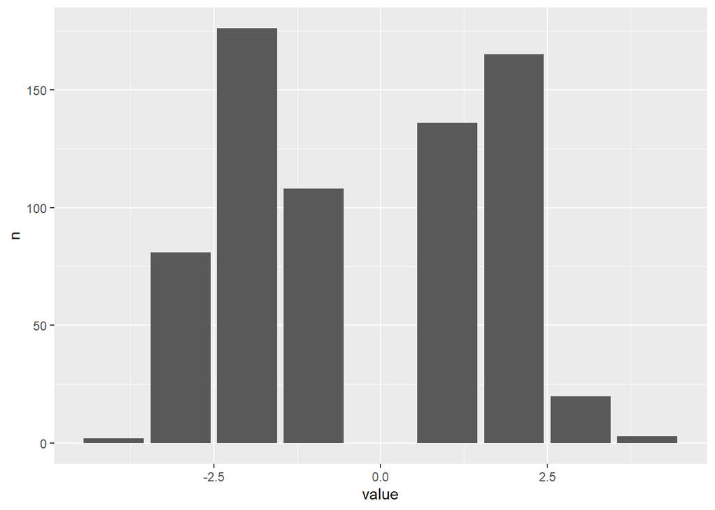

```r
ggplot(data = Aboriginal_1970_1979_afinn_hist, aes(x = value, y = n)) +
  geom_col()
```

## Aboriginal 1970 to 1979 afinn2

Here filter removes words that do not have a value on 2.

```r
Aboriginal_1970_1979_afinn2 <- Aboriginal_1970_1979_afinn %>%
  filter(value == 2)
```

## Unique 2 words score

```r
unique(Aboriginal_1970_1979_afinn2$word)
```

```
##  [1] "opportunity"     "acquitted"       "justified"       "support"
##  [5] "recommended"     "endorsement"     "improvement"     "approved"
##  [9] "sympathy"        "likes"           "benefit"         "endorse"
## [13] "success"         "peaceful"        "sincere"         "helpful"
## [17] "appreciated"     "amazed"          "honest"          "integrity"
## [21] "effectively"     "confident"       "sympathetic"     "trusted"
## [25] "hope"            "helping"         "gains"           "true"
## [29] "welcomed"        "responsible"     "honour"          "justice"
## [33] "strong"          "solidarity"      "save"            "supported"
## [37] "dedicated"       "advantage"       "hopes"           "stronger"
## [41] "care"            "enlightening"    "proud"           "worth"
## [45] "peace"           "fair"            "powerful"        "intact"
## [49] "progress"        "commitment"      "ratified"        "highlight"
## [53] "gained"          "generous"        "secure"          "assets"
## [57] "solid"           "effective"       "freedom"         "chance"
## [61] "congratulate"    "honor"           "gaining"         "gain"
## [65] "confidence"      "clean"           "meaningful"      "friendly"
## [69] "strength"        "smile"           "congratulations" "carefully"
## [73] "relaxed"         "ha"              "improved"        "remarkable"
## [77] "ability"         "rich"            "stable"          "worthy"
## [81] "resolved"        "comfortable"     "positive"        "growth"
## [85] "top"             "determined"
```

## Count plot Aboriginal 1970 til 1979 afinn2 n

```r
Aboriginal_1970_1979_afinn2_n<- Aboriginal_1970_1979_afinn2%>%
  count(word, sort = TRUE) %>%
  mutate(word = fct_reorder(factor(word), n))

Aboriginal_1970_1979_afinn2_n
```

```
## # A tibble: 86 × 2
##    word            n
##    <fct>       <int>
##  1 support        16
##  2 peace           6
##  3 solidarity      5
##  4 acquitted       4
##  5 benefit         4
##  6 opportunity     4
##  7 strong          4
##  8 success         4
##  9 sympathetic     4
## 10 true            4
## # ℹ 76 more rows
```

## Count and plot graph

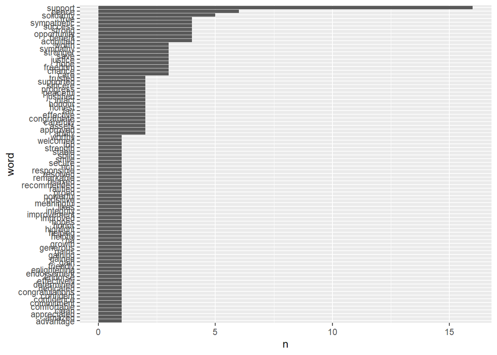

```r
ggplot(data = Aboriginal_1970_1979_afinn2_n, aes(x = word, y = n)) +
  geom_col() +
  coord_flip()
```

## Summerize sentiment

```r
Aboriginal_1970_1979_summery <- Aboriginal_1970_1979_afinn%>%
  summarise(mean_score = mean(value), median_score = median(value))

Aboriginal_1970_1979_summery
```

```
## # A tibble: 1 × 2
##   mean_score median_score
##        <dbl>        <dbl>
## 1     -0.250           -1
```

## Aboriginal 1970 til 1979 nrc

Inner join connects the stopwords column(word) with the nrc column(sentiment).

```r
Aboriginal_1970_1979_nrc <- Aboriginal_1970_1979_stop%>%
  inner_join(get_sentiments("nrc"))
```

## Exclude

Anti join finds all words that do not match two dataframes.

```r
Aboriginal_1970_1979_exclude <- Aboriginal_1970_1979_stop %>%
  anti_join(get_sentiments("nrc"))
Aboriginal_1970_1979_exclude
```

```
## # A tibble: 7,794 × 14
##    article_id article_URL     article_heading category article_date article_page
##         <dbl> <chr>           <chr>           <chr>    <date>              <dbl>
##  1  110833545 https://api.tr… Aboriginal      Article  1977-01-05              3
##  2  110833545 https://api.tr… Aboriginal      Article  1977-01-05              3
##  3  110833545 https://api.tr… Aboriginal      Article  1977-01-05              3
##  4  110833545 https://api.tr… Aboriginal      Article  1977-01-05              3
##  5  110833545 https://api.tr… Aboriginal      Article  1977-01-05              3
##  6  110833545 https://api.tr… Aboriginal      Article  1977-01-05              3
##  7  110833545 https://api.tr… Aboriginal      Article  1977-01-05              3
##  8  110833545 https://api.tr… Aboriginal      Article  1977-01-05              3
##  9  110833545 https://api.tr… Aboriginal      Article  1977-01-05              3
## 10  110833545 https://api.tr… Aboriginal      Article  1977-01-05              3
## # ℹ 7,784 more rows
## # ℹ 8 more variables: article_page_sequence <dbl>, article_snippet <chr>,
## #   article_Trove_URL <chr>, article_title_id <dbl>, article_title_title <chr>,
## #   article_relevance_score <dbl>, article_relevance_value <chr>, word <chr>
```

## Count most exluded

```r
Aboriginal_1970_1979_exclude_n <-  Aboriginal_1970_1979_exclude%>%
  count(word, sort = TRUE)

Aboriginal_1970_1979_exclude_n
```

```
## # A tibble: 3,314 × 2
##    word           n
##    <chr>      <int>
##  1 aboriginal   400
##  2 aborigines   104
##  3 people        93
##  4 affairs       61
##  5 australian    53
##  6 australia     51
##  7 white         46
##  8 rights        42
##  9 black         41
## 10 federal       38
## # ℹ 3,304 more rows
```

## Show Aboriginal 1970 to 1979 exclude n head

```r
head(Aboriginal_1970_1979_exclude_n)
```

```
## # A tibble: 6 × 2
##   word           n
##   <chr>      <int>
## 1 aboriginal   400
## 2 aborigines   104
## 3 people        93
## 4 affairs       61
## 5 australian    53
## 6 australia     51
```

## Emplot Aboriginal 1970 to 1979 nrc n

The x-axis(sentiment) is the type of sentiment while the y-axis(n) is the amount of a sentiment from the x-axis.

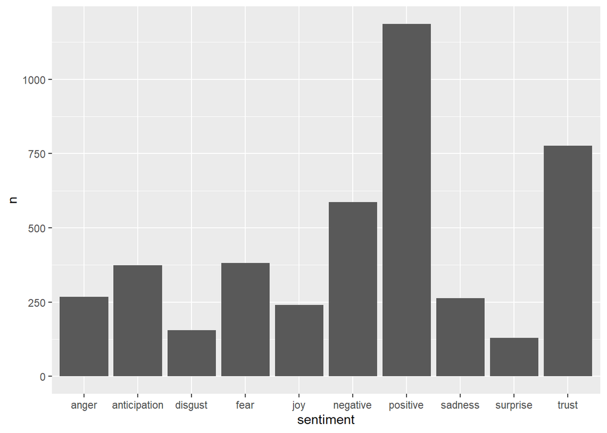

```r
Aboriginal_1970_1979_nrc_n <- Aboriginal_1970_1979_nrc %>%
  count(sentiment, sort = TRUE )

ggplot(data = Aboriginal_1970_1979_nrc_n, aes(x = sentiment, y = n)) +
  geom_col()
```

## Count sentiment and word

There are multiple graphs each divided by a sentiment and each have a x-axis which represents the amount of sentiment to a specific word from the y-axis.

```r
Aboriginal_1970_1979_nrc_n5 <- Aboriginal_1970_1979_nrc %>%
  count(word,sentiment,sort = TRUE) %>%
  group_by(sentiment) %>%
  top_n(5) %>%
  ungroup()
```

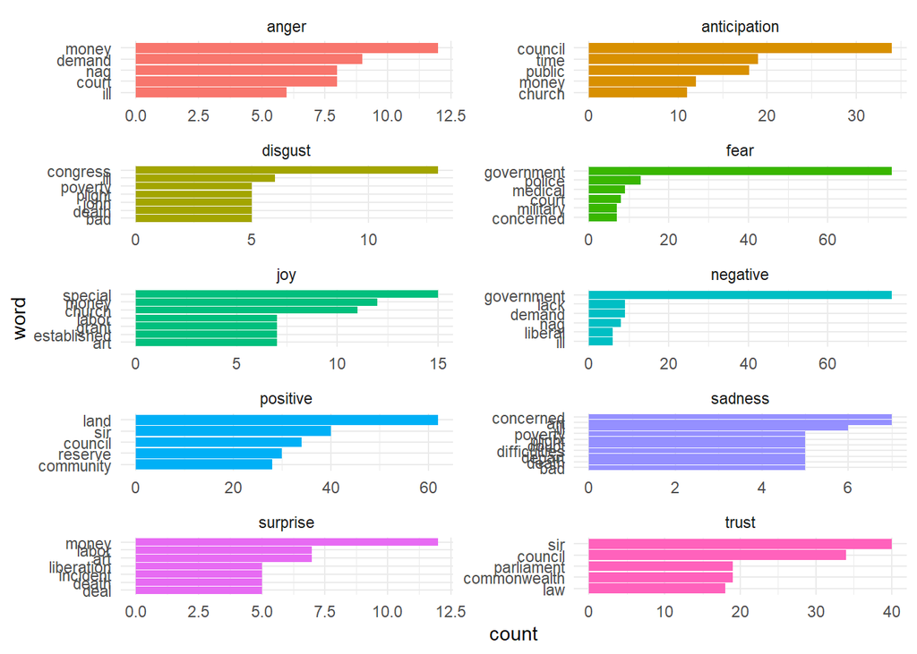

```r
Aboriginal_1970_1979_nrc_gg <- ggplot(data = Aboriginal_1970_1979_nrc_n5, aes(x = reorder(word,n), y = n, fill = sentiment)) +
  geom_col(show.legend = FALSE) +
  facet_wrap(~sentiment, ncol = 2, scales = "free") +
  coord_flip() +
  theme_minimal() +
  labs(x = "word" , y = "count")

Aboriginal_1970_1979_nrc_gg
```

## Save it

```r
ggsave(plot = Aboriginal_1970_1979_nrc_gg,
       filename ="figures/ipcc_nrc_sentiment.png",
      height = 8,
      width = 5)
```